# Final Project

Yiqian Xin, Laiang Yao & Yun YUan

2/28/2022

# Part One: Introduction

## Investigation of alcohol on sexual risk behavior among aging population in rural South Africa

Alcohol plays an important part in social networking. Alcohol consumption can improve positive emotions and have bonding effects in a social setting. However, alcohol consumed in excess amount and frequency is likely to be associated with a wide range of negative consequences: symptoms of a hangover, road traffic injuries, the risk factor of behavioral problems including aggression, self-disclosure, sexual adventuresomeness (Steele & Southwick, 1985). Globally, there are 3 million premature deaths resulting from harmful use of alcohol every year (WHO, 2018). While there has been significant literature dedicating to alcohol use and sexual assaults (Lorenz & Ullman, 2016), alcohol intoxication and men’s resistance to condom use (Davis et al., 2016), the relationship between alcohol use and sexual risk behaviors on a broader scope and extending to the general population remains unclear. The goal of this study was to investigate the association of alcohol use with related sexual risk behaviors among the Health and Ageing in Africa: a Longitudinal Study of an INDEPTH Community (HAALSI) cohort.  
During the wave 1 survey of the HAALSI study, 5,059 participants were randomly enrolled in the community-based survey. The response rate of the baseline survey was 89%. (HAALSI Data, n.d.) Alcohol consumption was collected by asking participants questions on the frequency of having at least one alcoholic drink (daily, 5-6 days per week, 1-4 days per week, 1-3 days per month, less than once per month). Due to missingness in the quantity of alcoholic drinks participants had on a typical day, the amount of alcohol consumed will be added in the subgroup analysis. In order to address the aforementioned gaps, we sought to describe aspects of sexual risk behavior including 1) number of different sexual partners; 2) if ever had sex without a condom when drunk; 3) if ever had sex in exchange for money, drugs, goods, or services. Baseline characteristics including sex, age, country of birth, education, marital status, HIV status are used to evaluate covariates.

# Part Two:Data

## Preparation

```r
# Load packages
library(tidyverse)
library(dataReporter)
```

## Variables

1. Alcohol consumption
- `CM069`: Do you currently (or in the last 30 days) consume any alcoholic drinks such as beer, wine, spirits, fermented cider, thothotho or traditional beer?
- `CM070`: How often do you have at least one alcoholic drink?
- `CM071`: On days you drink, how many alcoholic drinks do you have?
2. Sexual risk behavior
- `HV017`: Do/did you use a condom with your most recent partner? **None**
- `HV019`: Have you had vaginal or anal sex without a condom when you were drunk or buzzed on alcohol or high on any other drug?
- `HV020`: Have you ever had sex in exchange for money?
- `HV021`: When having sex for money, did you us a condom?
- `HV022`: Have you ever had sex without a condom with someone HIV positive?
- `HV003`: How many different sex partners have you had in your lifetime?
- `HV005`: During the last 24 months, how many sexual partners have you had?
3. HIV infection
- `CM014`: Have you ever tested positive for HIV?
4. Demographic variables
- `BD002`: How old are you (in completed years)? - age
- `BD036`: What is the highest level of education you have attained? - education
- `BD038`: At what age did you begin formal schooling? - education **None**
- `BD039`: At what age did you finish schooling? - education **None**
- `BD003`: What is your current marital status? - marital status
- Wealth index

```r
# Import data
load("/Users/apple/Desktop/glhlth562/materials/final/data/HAALSI_baseline_dataverse_14Apr2017.RData")
haalsi <- x %>%
  select(prim_key, cm069, cm070, cm071, hv019, hv020, hv021, hv022, hv003, hv005, cm014, bd002, bd003, bd036, c_bd_country, c_bd_educ4)

head(haalsi)
```

```
##   prim_key       cm069                cm070 cm071               hv019     hv020
## 1    BBBNE 1 (YES) Yes 4 1-3 days per month  <NA>                2 No 2 (NO) No
## 2    BBBTW        <NA>                 <NA>  <NA>                <NA>      <NA>
## 3    BBCCY        <NA>                 <NA>  <NA>                2 No 2 (NO) No
## 4    BBCNO   2 (NO) No                 <NA>  <NA>                2 No 2 (NO) No
## 5    BBDXD   2 (NO) No                 <NA>  <NA>                2 No 2 (NO) No
## 6    BBEGB   2 (NO) No                 <NA>  <NA> 3 I do not remember 2 (NO) No
##   hv021     hv022 hv003 hv005       cm014 bd002
## 1  <NA> 2 (NO) No    NA     1 1 (YES) Yes    50
## 2  <NA>      <NA>    NA    NA   2 (NO) No    64
## 3  <NA> 2 (NO) No     3     0   2 (NO) No    49
## 4  <NA> 2 (NO) No    38     1   2 (NO) No    55
## 5  <NA> 2 (NO) No     3     1   2 (NO) No    84
## 6  <NA> 2 (NO) No    NA     1   2 (NO) No    68
##                                        bd003             bd036 c_bd_country
## 1 2 Currently married or living with partner        1 (N) None South Africa
## 2 2 Currently married or living with partner        1 (N) None South Africa
## 3                                  5 Widowed 10 (6) Std 6/Gr 8 South Africa
## 4                       3 Separated/Deserted  7 (3) Std 3/Gr 5 South Africa
## 5                                 4 Divorced        1 (N) None South Africa
## 6 2 Currently married or living with partner  6 (2) Std 2/Gr 4 South Africa
##                    c_bd_educ4
## 1         No formal education
## 2         No formal education
## 3 Some secondary (8-11 years)
## 4    Some primary (1-7 years)
## 5         No formal education
## 6    Some primary (1-7 years)
```

## Data wrangling

```r
# Tabulation
table(haalsi$cm069, useNA = "always")
```

```
##
## 1 (YES) Yes   2 (NO) No        <NA>
##        1171        1084        2804
```

```r
table(haalsi$cm070, useNA = "always")
```

```
##
##                    1 Daily        2 5-6 days per week
##                        167                        137
##        3 1-4 days per week       4 1-3 days per month
##                        315                        317
## 5 Less than once per month                       <NA>
##                        234                       3889
```

```r
table(haalsi$cm071, useNA = "always")
```

```
##
## 1 less than 1         2 1-2         3 3-4   4 5 or more          <NA>
##             9            48            64            44          4894
```

```r
table(haalsi$hv019, useNA = "always")
```

```
##
##               1 Yes                2 No 3 I do not remember                <NA>
##                 726                4093                  49                 191
```

```r
table(haalsi$hv020, useNA = "always")
```

```
##
## 1 (YES) Yes   2 (NO) No        <NA>
##          21        4851         187
```

```r
table(haalsi$hv021, useNA = "always")
```

```
##
##               1 Yes                2 No 3 I do not remember                <NA>
##                   3                  18                   0                5038
```

```r
table(haalsi$hv022, useNA = "always")
```

```
##
## 1 (YES) Yes   2 (NO) No        <NA>
##          77        4727         255
```

```r
table(haalsi$cm014, useNA = "always")
```

```
##
## 1 (YES) Yes   2 (NO) No        <NA>
##         623        4402          34
```

```r
table(haalsi$bd003, useNA = "always")
```

```
##
##                            1 Never married
##                                        290
## 2 Currently married or living with partner
##                                       2575
##                       3 Separated/Deserted
##                                        414
##                                 4 Divorced
##                                        236
##                                  5 Widowed
##                                       1540
##                                       <NA>
##                                          4
```

```r
table(haalsi$c_bd_educ4, useNA = "always")
```

```
##
##           No formal education      Some primary (1-7 years)
##                          2306                          1716
##   Some secondary (8-11 years) Secondary or more (12+ years)
##                           574                           446
##                          <NA>
##                            17
```

```r
table(haalsi$c_bd_country, useNA = "always")
```

```
##
##     South Africa Mozambique/other             <NA>
##             3528             1526                5
```

```r
# Wrangling
baseline <- haalsi %>%
  mutate(alc_consumption = recode(cm069,
                                  "1 (YES) Yes" = 1,
                                  "2 (NO) No" = 0),
         alc_freq = recode(cm070,
                           "5 Less than once per month" = 1,
                           "4 1-3 days per month" = 2,
                           "3 1-4 days per week" = 3,
                           "2 5-6 days per week" = 4,
                           "1 Daily" = 5),
         alc_amount = recode(cm071,
                             "1 less than 1 " = 1,
                             "2 1-2" = 2,
                             "3 3-4" = 3,
                             "4 5 or more" = 4),
         sex_risk = recode(hv019,
                           "1 Yes" = 1,
                           "2 No" = 0
                           # "3 I do not remember" = NA
                           ),
         sex_work = recode(hv020,
                           "1 (YES) Yes" = 1,
                           "2 (NO) No" = 0),
         sex_work_condom = recode(hv021,
                                  "1 Yes" = 1,
                                  "2 No" = 0
                                  # "3 I do not remember" = NA
                                  ),
         sex_hiv = recode(hv022,
                          "1 (YES) Yes" = 1,
                          "2 (NO) No" = 0),
         sex_partners = hv003,
         sex_partners_24 = hv005,
         hiv_positive = recode(cm014,
                               "1 (YES) Yes" = 1,
                               "2 (NO) No" = 0),
         age = bd002,
         marital_status = case_when(bd003 %in% c("1 Never married",
                                                 "3 Separated/Deserted",
                                                 "4 Divorced",
                                                 "5 Widowed") ~ 0,
                                    bd003 == "2 Currently married or living with partner" ~ 1)) %>%
  select(prim_key, alc_consumption, alc_freq, alc_amount,
         sex_risk, sex_work, sex_work_condom, sex_hiv,
         sex_partners, sex_partners_24, hiv_positive,
         age, marital_status, c_bd_country, c_bd_educ4)

# baseline$alc_consumption <- factor(baseline$alc_consumption)
# baseline$alc_freq <- factor(baseline$alc_freq)
# baseline$alc_amount <- factor(baseline$alc_amount)
# baseline$sex_risk <- factor(baseline$sex_risk)
# baseline$sex_work <- factor(baseline$sex_work)
# baseline$sex_work_condom <- factor(baseline$sex_work_condom)
# baseline$sex_hiv <- factor(baseline$sex_hiv)
# baseline$hiv_positive <- factor(baseline$hiv_positive)
# baseline$marital_status <- factor(baseline$marital_status)
```

# Part three: Data Analysis Plan

## Preliminary exploration and visulization

```r
# Fig. 1. Descriptive analysis of alcohol consumption
# Recode alc_consumption and alc_freq into one variable.
table(baseline$alc_consumption, useNA = "always")
```

```
##
##    0    1 <NA>
## 1084 1171 2804
```

```r
table(baseline$alc_freq, useNA = "always")
```

```
##
##    1    2    3    4    5 <NA>
##  234  317  315  137  167 3889
```

```r
baseline$alc <- baseline$alc_freq
baseline$alc[baseline$alc_consumption == 0] <- 0
table(baseline$alc, useNA = "always")
```

```
##
##    0    1    2    3    4    5 <NA>
## 1084  234  317  315  137  167 2805
```

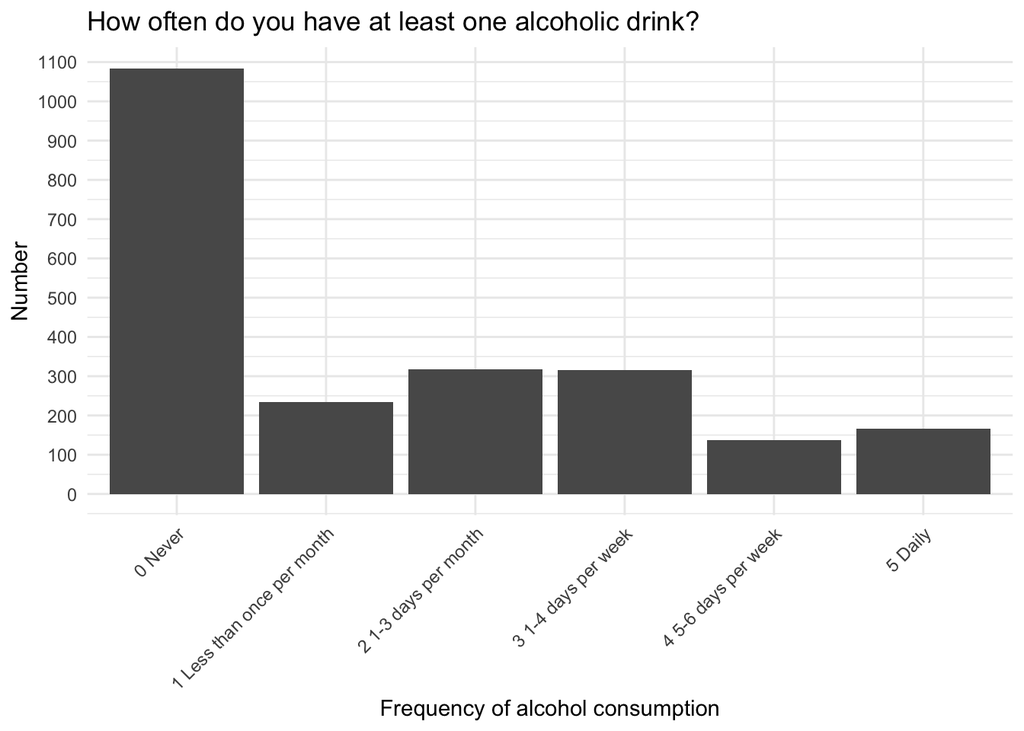

```r
baseline$alc <- car::recode(baseline$alc,
                                    "0 = '0 Never';
                                    1 = '1 Less than once per month';
                                    2 = '2 1-3 days per month';
                                    3 = '3 1-4 days per week';
                                    4 = '4 5-6 days per week';
                                    5 = '5 Daily'")

  ggplot(data = subset(baseline, !is.na(alc)), aes(x = alc)) +
    geom_bar() +
    theme_minimal() +
    labs(x = 'Frequency of alcohol consumption',
      y = 'Number',
      title='How often do you have at least one alcoholic drink?') +
    theme(axis.text.x = element_text(angle = 45, hjust = 1)) +
    scale_y_continuous(breaks = seq(from = 0, to = 1200, by = 100))
```

```r
# Fig. 2. Descriptive analysis of condom use (2 variables)
# Use sex_risk/hv019 and sex_hiv/hv022.
# sex_risk/hv019 - Have you had vaginal or anal sex without a condom when you were drunk or buzzed on alcohol or high on any other drug?
# sex_hiv/hv022 - Have you ever had sex without a condom with someone you know is HIV positive?
table(baseline$sex_risk, useNA = "always")
```

```
##
##    0    1 <NA>
## 4093  726  240
```

```r
table(baseline$sex_hiv, useNA = "always")
```

```
##
##    0    1 <NA>
## 4727   77  255
```

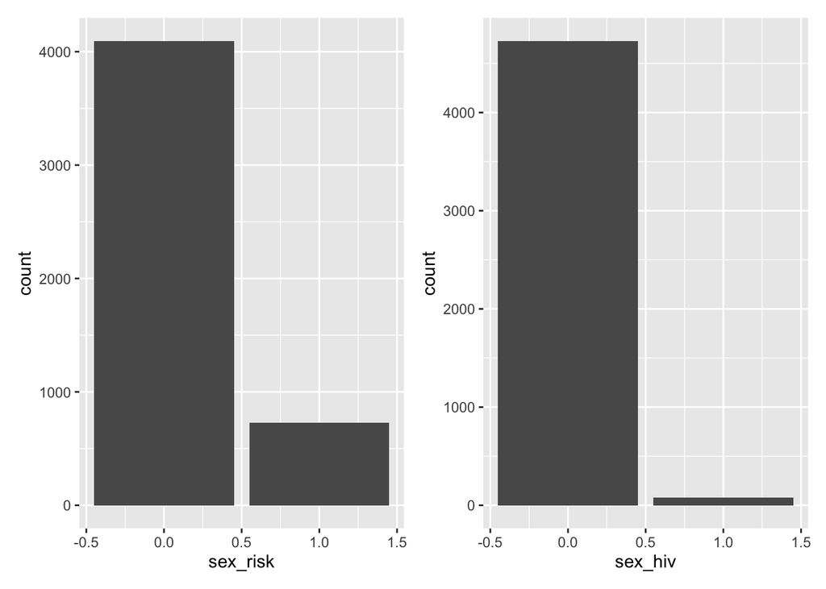

```r
library(patchwork)
p1 <- ggplot(data = subset(baseline, !is.na(sex_risk)), aes(x = sex_risk)) +
    geom_bar()
p2 <- ggplot(data = subset(baseline, !is.na(sex_hiv)), aes(x = sex_hiv)) +
    geom_bar()
p1 + p2
```

```r
# Fig. 3. Descriptive analysis of sexual partners (2 variables)
# Use sex_partners/hv003 and sex_partners_24/hv005.
# sex_partners/hv003 - How many different sexual partners have you had in your lifetime?
# sex_partners_24/hv005 - During the last 24 months (that is since ^FLHV005), how many sexual partners have you had?
table(baseline$sex_partners, useNA = "always")
```

```
##
##    0    1    2    3    4    5    6    7    8    9   10   11   12   13   14   15
##   34 1455  858  531  336  319  143  104   92   37  193   16   60   16   16   86
##   16   17   18   19   20   21   22   23   24   25   26   27   30   31   32   35
##   12   19   11    3   49    1    6    3    1   14    1    1   25    1    1    3
##   38   40   43   45   46   48   50   56   57   60   67   78   82  100  120 <NA>
##    1    8    1    2    1    1   17    1    1    2    1    1    1    6    3  565
```

```r
table(baseline$sex_partners_24, useNA = "always")
```

```
##
##    0    1    2    3    4    5    6    7   10   11   20 <NA>
## 2118 2537  176   36    5    5    1    2    1    1    1  176
```

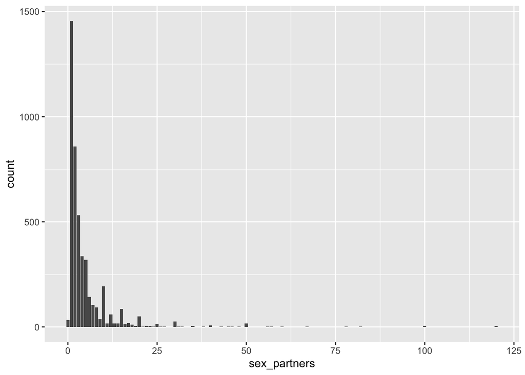

```r
ggplot(data = baseline, mapping = aes(x = sex_partners)) +
  geom_bar()
```

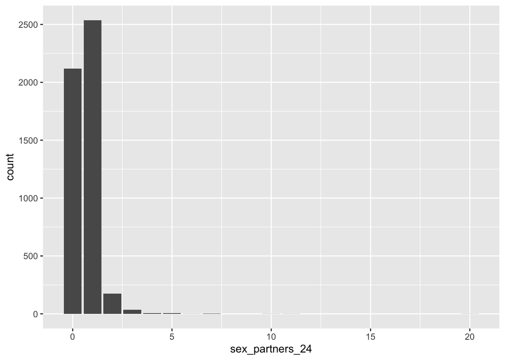

```r
ggplot(data = baseline, mapping = aes(x = sex_partners_24)) +
  geom_bar()
```

## References

Davis, K. C., Danube, C. L., Neilson, E. C., Stappenbeck, C. A., Norris, J., George, W. H., & Kajumulo, K. F. (2016). Distal and Proximal Influences on Men’s Intentions to Resist Condoms: Alcohol, Sexual Aggression History, Impulsivity, and Social-Cognitive Factors. AIDS and Behavior, 20(S1), 147–157. https://doi.org/10.1007/s10461-015-1132-9 HAALSI Data. (n.d.). Retrieved February 27, 2022, from https://haalsi.org/data Lorenz, K., & Ullman, S. E. (2016). Alcohol and sexual assault victimization: Research findings and future directions. Aggression and Violent Behavior, 31, 82–94. https://doi.org/10.1016/j.avb.2016.08.001 Steele, C. M., & Southwick, L. (1985). Alcohol and social behavior: I. The psychology of drunken excess. Journal of Personality and Social Psychology, 48(1), 18–34. https://doi.org/10.1037/0022-3514.48.1.18 WHO. (2018, September 21). Fact sheet on alcohol. https://www.who.int/news-room/fact-sheets/detail/alcohol